# Lecture 13: Missing Data via Bayesian

Bayesian Psychometric Modeling

```r
# Install/Load Packages ===============================================================================================
if (!require(R2jags)) install.packages("R2jags")
```

```
## Linked to JAGS 4.3.0
```

```
## Loaded modules: basemod,bugs
```

```r
library(R2jags)

if (!require(mcmcplots)) install.packages("mcmcplots")
library(mcmcplots)
```

## Bayesian Methods for Missing Data

Look up the word “missing” from the JAGS user manual (v. 4.3; available at (http://people.stat.sc.edu/hansont/stat740/jags_user_manual.pdf)[http://people.stat.sc.edu/hansont/stat740/jags_user_manual.pdf]) and you will find only three cases: two regarding how missing data should be input into JAGS and one talking about missing values in initialized parameters. Despite this, Bayesian methods missing data are some of the more powerful techniques around.

Let’s take an example. Say we create:

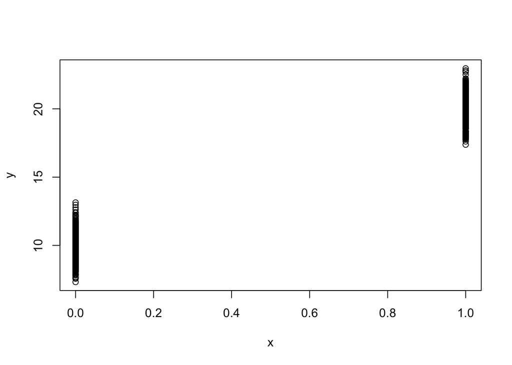

```r
set.seed(007)
nObs = 1000
nMiss = 1

# for x
probX = .5

# for y|x
beta0 = 10
beta1 = 10
sigma2e = 1

# generate x, then y
x = rbinom(n = nObs, size = 1, prob = probX)
y = beta0 + beta1*x + rnorm(n = nObs, mean = 0, sd = sqrt(sigma2e))

# make one value of X missing
x[sample(x = 1:nObs, size = nMiss, replace = FALSE)] = NA
x[1]= NA
# show plot
plot(x = x, y = y)
```

Bayesian missing data methods use Bayes Theorem to “impute” values of missing data using specs from a simultaneous analysis. For instance, we could model:

$$Prob(x_p = 1) = \pi_x,$$

where $x_p \sim B(\pi_x)$, simultaneous to:

$$y_p = \beta_0 + \beta_1x_p + e_p,$$

where $y_p|x_p \sim N(\beta_0+\beta_1x_p, \sigma^2_e)$.

Here, should we have a missing $x_p$, we can use Bayes’ theorem to determine the distribution of the observation:

$$f(x_p|y_p) \propto f(y_p|x_p)f(x_p),$$

Where $f(y_p|x_p)$ is our regression model and $f(x_p)$ is the distribution of $x_p$, or Bernoulli.

We can even make this work in JAGS:

```r
model01.function = function(){
  for (i in 1:N){
    x[i] ~ dbern(pi)
    y[i] ~ dnorm(beta0+beta1*x[i], sigma2.inv)
  }

  pi ~ dbeta(1,1)
  sigma2.inv ~ dgamma(4, 8)
  sigma2 <- 1/sigma2.inv

  beta0 ~ dnorm(0, .00001)
  beta1 ~ dnorm(0, .00001)
}

# next, create data for JAGS to use:
model01.data = list(
  N = length(x),
  x = x,
  y = y
)

model01.parameters = c("beta0", "beta1", "sigma2", "pi", "x[1]")

model01.seed = 23042019

model01.r2jags =  jags.parallel(
  data = model01.data,
  parameters.to.save = model01.parameters,
  model.file = model01.function,
  n.chains = 4,
  n.iter = 2000,
  n.thin = 1,
  n.burnin = 1000,
  jags.seed = model01.seed
)

model01.r2jags
```

```
## Inference for Bugs model at "model01.function", fit using jags,
##  4 chains, each with 2000 iterations (first 1000 discarded)
##  n.sims = 4000 iterations saved
##           mu.vect sd.vect     2.5%      25%      50%      75%    97.5%
## beta0       9.936   0.054    9.848    9.907    9.937    9.966   10.024
## beta1      10.073   0.072    9.944   10.030   10.073   10.115   10.195
## pi          0.494   0.016    0.464    0.483    0.494    0.505    0.525
## sigma2      1.244   7.919    0.908    0.963    0.992    1.024    1.083
## x[1]        0.999   0.027    1.000    1.000    1.000    1.000    1.000
## deviance 4211.225 143.896 4202.918 4204.435 4205.919 4208.015 4213.691
##           Rhat n.eff
## beta0    1.021  4000
## beta1    1.005  4000
## pi       1.001  4000
## sigma2   1.001  4000
## x[1]     1.157  3300
## deviance 1.000  4000
##
## For each parameter, n.eff is a crude measure of effective sample size,
## and Rhat is the potential scale reduction factor (at convergence, Rhat=1).
##
## DIC info (using the rule, pD = var(deviance)/2)
## pD = 10360.8 and DIC = 14572.1
## DIC is an estimate of expected predictive error (lower deviance is better).
```

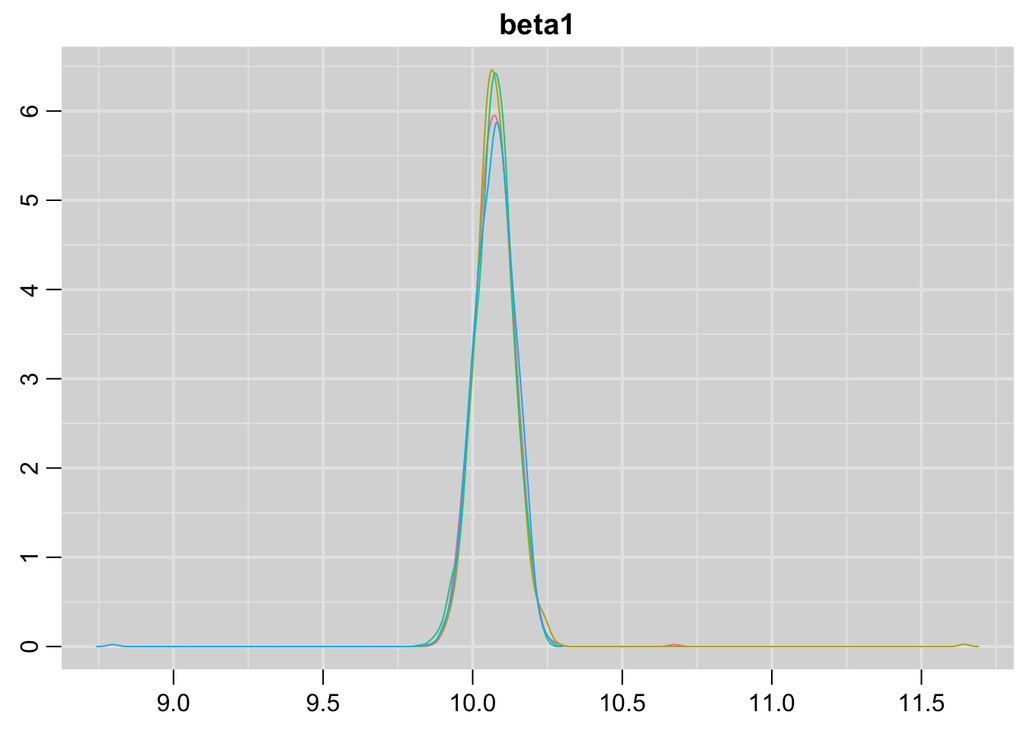

```r
denplot(model01.r2jags, parms = "beta1")
```

```r
model01.r2jags$BUGSoutput$sims.matrix[,6]
```

[output not shown]

[output cut: 103 more lines]

Comparing this with just modeling $x_p$, we see a difference:

```r
model02.function = function(){
  for (i in 1:N){
    x[i] ~ dbern(pi)
    y[i] ~ dnorm(beta0+beta1*x[i], sigma2.inv)
  }

  pi ~ dbeta(1,1)
  sigma2.inv ~ dgamma(4, 8)
  sigma2 <- 1/sigma2.inv

  beta0 ~ dnorm(0, .00001)
  beta1 <- 0
}

model02.r2jags = jags.parallel(
  data = model01.data,
  parameters.to.save =  c("beta0", "beta1", "sigma2", "pi", "x[1]"),
  model.file = model02.function,
  n.chains = 4,
  n.iter = 2000,
  n.thin = 1,
  n.burnin = 1000,
  jags.seed = model01.seed+1
)
model02.r2jags
```

```
## Inference for Bugs model at "model02.function", fit using jags,
##  4 chains, each with 2000 iterations (first 1000 discarded)
##  n.sims = 4000 iterations saved
##           mu.vect sd.vect     2.5%      25%      50%      75%    97.5%
## beta0      14.917   0.161   14.603   14.809   14.917   15.027   15.220
## beta1       0.000   0.000    0.000    0.000    0.000    0.000    0.000
## pi          0.494   0.016    0.463    0.483    0.494    0.505    0.524
## sigma2     26.473   7.123   24.063   25.448   26.219   27.003   28.647
## x[1]        0.494   0.500    0.000    0.000    0.000    1.000    1.000
## deviance 7496.800  42.645 7492.698 7493.716 7494.851 7496.510 7501.888
##           Rhat n.eff
## beta0    1.001  4000
## beta1    1.000     1
## pi       1.001  4000
## sigma2   1.001  4000
## x[1]     1.001  3200
## deviance 1.001  4000
##
## For each parameter, n.eff is a crude measure of effective sample size,
## and Rhat is the potential scale reduction factor (at convergence, Rhat=1).
##
## DIC info (using the rule, pD = var(deviance)/2)
## pD = 910.0 and DIC = 8406.8
## DIC is an estimate of expected predictive error (lower deviance is better).
```

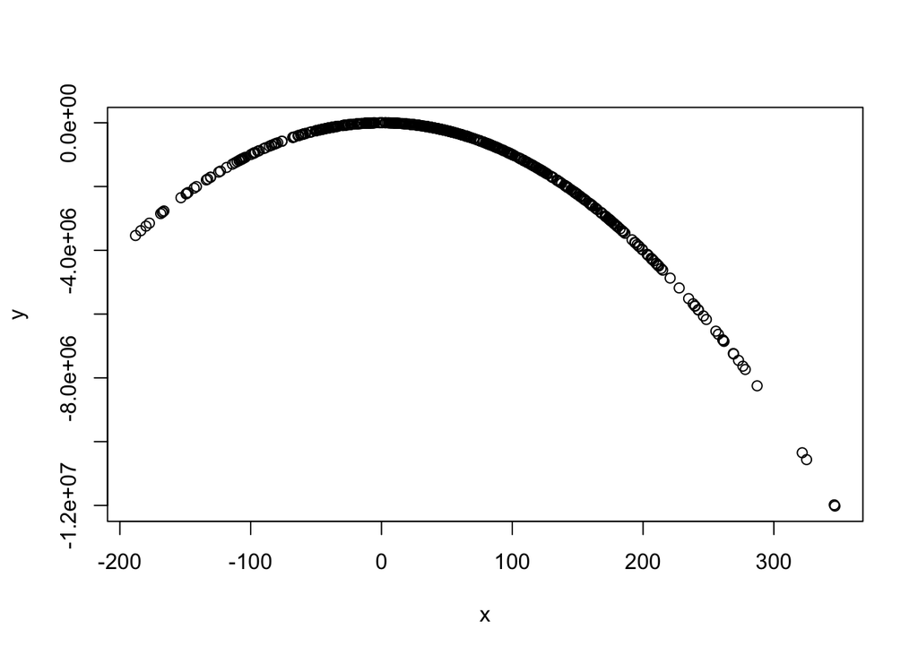

```r
set.seed(007)
nObs = 1000
nMiss = 400

# for x
meanX = 50
sdX = 100

# for y|x
beta0 = 0
beta1 = 0
beta2 = -100
sigma2e = 1

# generate x, then y
x = rnorm(n = nObs, mean = meanX, sd = sdX)
y = beta0 + beta1*x + beta2*x^2 + rnorm(n = nObs, mean = 0, sd = sqrt(sigma2e))

# make one value of X missing
x[sample(x = 1:nObs, size = nMiss, replace = FALSE)] = NA
x[1]= NA
# show plot
plot(x = x, y = y)
```

```r
model01.function = function(){
  for (i in 1:N){
    x[i] ~ dnorm(meanX, sigma2.invX)
    y[i] ~ dnorm(beta0+beta1*x[i], sigma2.inv)
  }

  sigma2.invX ~ dgamma(1000, 2)
  sigma2.inv ~ dgamma(4, 8)
  sigma2 <- 1/sigma2.inv
  sigma2X <- 1/sigma2.inv
  beta0 ~ dnorm(0, .00001)
  meanX ~ dnorm(0, .00001)
  beta1 ~ dnorm(0, .00001)
}

# next, create data for JAGS to use:
model01.data = list(
  N = length(x),
  x = x,
  y = y
)

model01.parameters = c("beta0", "beta1", "sigma2", "sigma2X", "meanX", "x", "y")

model01.seed = 23042019

model01.r2jags =  jags.parallel(
  data = model01.data,
  parameters.to.save = model01.parameters,
  model.file = model01.function,
  n.chains = 4,
  n.iter = 2000,
  n.thin = 1,
  n.burnin = 1000,
  jags.seed = model01.seed
)

model01.r2jags
```

```
## Inference for Bugs model at "model01.function", fit using jags,
##  4 chains, each with 2000 iterations (first 1000 discarded)
##  n.sims = 4000 iterations saved
##                mu.vect      sd.vect          2.5%           25%
## beta0    -3.530300e+01 3.179190e+02 -6.718110e+02 -2.455270e+02
## beta1    -3.084472e+03 3.124120e+02 -3.699578e+03 -3.289939e+03
## meanX     5.789200e+01 2.031000e+00  5.421000e+01  5.662800e+01
## sigma2    3.526054e+12 1.725851e+11  3.206018e+12  3.408597e+12
## sigma2X   3.526054e+12 1.725851e+11  3.206018e+12  3.408597e+12
## x[1]      7.190800e+01 4.595900e+01 -1.838600e+01  4.138400e+01
## x[2]      5.822400e+01 4.610500e+01 -3.002000e+01  2.687700e+01
## x[3]      5.704500e+01 4.686200e+01 -3.445100e+01  2.519800e+01
## x[4]      5.632900e+01 4.587700e+01 -3.124700e+01  2.527300e+01
## x[5]      5.783300e+01 4.666600e+01 -3.334600e+01  2.692400e+01
## x[6]      5.745800e+01 4.639700e+01 -3.419600e+01  2.567300e+01
## x[7]      6.173800e+01 4.710700e+01 -2.953000e+01  3.030700e+01
## x[8]      3.830400e+01 0.000000e+00  3.830400e+01  3.830400e+01
## x[9]      6.526600e+01 0.000000e+00  6.526600e+01  6.526600e+01
## x[10]     2.689980e+02 0.000000e+00  2.689980e+02  2.689980e+02
## x[11]     8.569900e+01 0.000000e+00  8.569900e+01  8.569900e+01
## x[12]     3.216750e+02 0.000000e+00  3.216750e+02  3.216750e+02
## x[13]     2.781450e+02 0.000000e+00  2.781450e+02  2.781450e+02
## x[14]     6.007900e+01 4.646200e+01 -2.876400e+01  2.767600e+01
## x[15]     2.396070e+02 0.000000e+00  2.396070e+02  2.396070e+02
## x[16]     5.950600e+01 4.611600e+01 -3.282300e+01  2.853500e+01
## x[17]     5.663000e+01 4.625200e+01 -3.252500e+01  2.506900e+01
## x[18]     5.782300e+01 4.520900e+01 -2.956300e+01  2.746000e+01
## x[19]     4.951800e+01 0.000000e+00  4.951800e+01  4.951800e+01
## x[20]     1.488160e+02 0.000000e+00  1.488160e+02  1.488160e+02
## x[21]     1.339750e+02 0.000000e+00  1.339750e+02  1.339750e+02
## x[22]     6.176100e+01 4.550000e+01 -2.466600e+01  3.117600e+01
## x[23]     1.805960e+02 0.000000e+00  1.805960e+02  1.805960e+02
## x[24]     5.847200e+01 4.630000e+01 -3.115000e+01  2.720100e+01
## x[25]     1.772920e+02 0.000000e+00  1.772920e+02  1.772920e+02
## x[26]     5.819900e+01 4.688200e+01 -3.143400e+01  2.648400e+01
## x[27]     1.252280e+02 0.000000e+00  1.252280e+02  1.252280e+02
## x[28]     1.091750e+02 0.000000e+00  1.091750e+02  1.091750e+02
## x[29]     5.776800e+01 4.637000e+01 -3.386300e+01  2.672900e+01
## x[30]     2.239400e+01 0.000000e+00  2.239400e+01  2.239400e+01
## x[31]    -3.708500e+01 0.000000e+00 -3.708500e+01 -3.708500e+01
```

[output cut: 3969 more lines]

```
## y[994]   -1.259416e+06 -1.259416e+06 -1.259416e+06 1.000     1
## y[995]   -2.133091e+06 -2.133091e+06 -2.133091e+06 1.000     1
## y[996]   -7.326669e+05 -7.326669e+05 -7.326669e+05 1.000     1
## y[997]   -5.135196e+04 -5.135196e+04 -5.135196e+04 1.000     1
## y[998]   -3.981738e+06 -3.981738e+06 -3.981738e+06 1.000     1
## y[999]   -1.946454e+06 -1.946454e+06 -1.946454e+06 1.000     1
## y[1000]  -3.387527e+06 -3.387527e+06 -3.387527e+06 1.000     1
## deviance  4.002741e+04  4.006737e+04  4.014231e+04 1.001  4000
##
## For each parameter, n.eff is a crude measure of effective sample size,
## and Rhat is the potential scale reduction factor (at convergence, Rhat=1).
##
## DIC info (using the rule, pD = var(deviance)/2)
## pD = 1714.6 and DIC = 41742.3
## DIC is an estimate of expected predictive error (lower deviance is better).
```

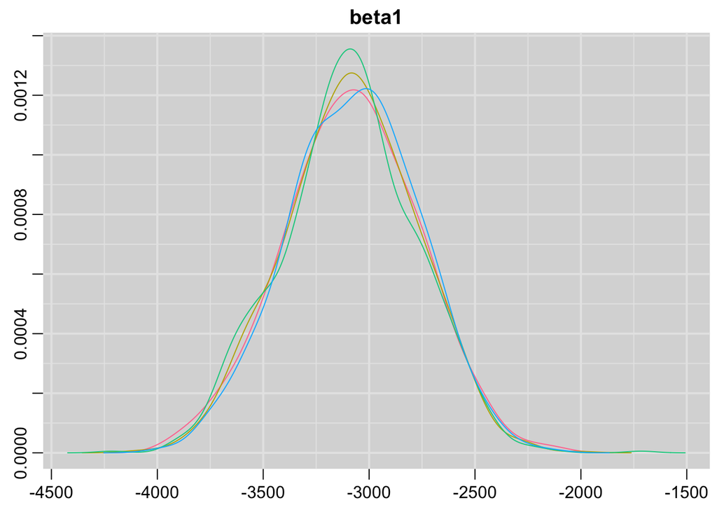

```r
denplot(model01.r2jags, parms = "beta1")
```

```r
model01.r2jags$BUGSoutput$sims.matrix[,6]
```

[output not shown]

[output cut: 785 more lines]

```r
colnames(model01.r2jags$BUGSoutput$sims.matrix)
```

```
##    [1] "beta0"    "beta1"    "deviance" "meanX"    "sigma2"   "sigma2X"
##    [7] "x[1]"     "x[2]"     "x[3]"     "x[4]"     "x[5]"     "x[6]"
##   [13] "x[7]"     "x[8]"     "x[9]"     "x[10]"    "x[11]"    "x[12]"
##   [19] "x[13]"    "x[14]"    "x[15]"    "x[16]"    "x[17]"    "x[18]"
##   [25] "x[19]"    "x[20]"    "x[21]"    "x[22]"    "x[23]"    "x[24]"
##   [31] "x[25]"    "x[26]"    "x[27]"    "x[28]"    "x[29]"    "x[30]"
##   [37] "x[31]"    "x[32]"    "x[33]"    "x[34]"    "x[35]"    "x[36]"
##   [43] "x[37]"    "x[38]"    "x[39]"    "x[40]"    "x[41]"    "x[42]"
##   [49] "x[43]"    "x[44]"    "x[45]"    "x[46]"    "x[47]"    "x[48]"
##   [55] "x[49]"    "x[50]"    "x[51]"    "x[52]"    "x[53]"    "x[54]"
##   [61] "x[55]"    "x[56]"    "x[57]"    "x[58]"    "x[59]"    "x[60]"
##   [67] "x[61]"    "x[62]"    "x[63]"    "x[64]"    "x[65]"    "x[66]"
##   [73] "x[67]"    "x[68]"    "x[69]"    "x[70]"    "x[71]"    "x[72]"
##   [79] "x[73]"    "x[74]"    "x[75]"    "x[76]"    "x[77]"    "x[78]"
##   [85] "x[79]"    "x[80]"    "x[81]"    "x[82]"    "x[83]"    "x[84]"
```

[output cut: 320 more lines]

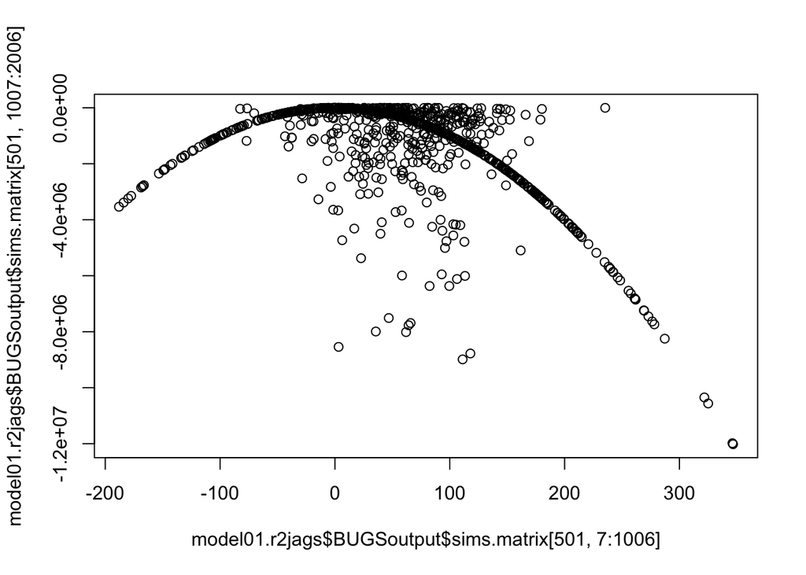

```r
plot(x = model01.r2jags$BUGSoutput$sims.matrix[501, 7:1006],
     y = model01.r2jags$BUGSoutput$sims.matrix[501, 1007:2006])
```

## Missing Item Response Example

We can show the same result in an IRT model when we make an observation missing as well. Let’s revisit our conspiracy theories example:

```r
# read in data:
conspiracy = read.csv("conspiracies.csv")
```

```r
conspiracy[4,1] = NA
```

Here, the frustrating part of JAGS kicks in: A matrix of data cannot have any missing values. So, everything has to be a vector. Note the extra syntax below (and also note there may be an easier way, but not one I could discover while prepping this lecture).

```r
# marker item:
model03.function = function(){

  # measurement model specification
    for (person in 1:N){

      # item 1 ---
      # form cumulative probability item response functions
      CProb1[person, 1] <- 1
      for (cat in 2:5){
        CProb1[person, cat] <- phi(a1*(theta[person]-b1[(cat-1)]))
      }

      # form probability response is equal to each category
      for (cat in 1:4){
        Prob1[person, cat] <- CProb1[person, cat] - CProb1[person, cat+1]
      }
      Prob1[person, 5] <- CProb1[person, 5]
      item1[person] ~ dcat(Prob1[person, 1:5])

      # item 2 ---
      # form cumulative probability item response functions
      CProb2[person, 1] <- 1
      for (cat in 2:5){
        CProb2[person, cat] <- phi(a2*(theta[person]-b2[(cat-1)]))
      }

      # form probability response is equal to each category
      for (cat in 1:4){
        Prob2[person, cat] <- CProb2[person, cat] - CProb2[person, cat+1]
      }
      Prob2[person, 5] <- CProb2[person, 5]
      item2[person] ~ dcat(Prob2[person, 1:5])

      # item 3 ---
      # form cumulative probability item response functions
      CProb3[person, 1] <- 1
      for (cat in 2:5){
        CProb3[person, cat] <- phi(a3*(theta[person]-b3[(cat-1)]))
      }

      # form probability response is equal to each category
      for (cat in 1:4){
        Prob3[person, cat] <- CProb3[person, cat] - CProb3[person, cat+1]
      }
      Prob3[person, 5] <- CProb3[person, 5]
      item3[person] ~ dcat(Prob3[person, 1:5])

    }

  # prior distributions for the factor:
    for (person in 1:N){
      theta[person] ~ dnorm(0, 1)
    }

  # prior distributions for the measurement model mean/precision parameters

    for (cat in 1:4){
      b1.star[cat] ~ dnorm(b.mean.0, b.precision.0)
      b2.star[cat] ~ dnorm(b.mean.0, b.precision.0)
      b3.star[cat] ~ dnorm(b.mean.0, b.precision.0)
    }
    b1[1:4] <- sort(b1.star[1:4])
    b2[1:4] <- sort(b2.star[1:4])
    b3[1:4] <- sort(b3.star[1:4])

    # loadings are set to be all positive
    a1 ~ dnorm(a.mean.0, a.precision.0);T(0,)
    a2 ~ dnorm(a.mean.0, a.precision.0);T(0,)
    a3 ~ dnorm(a.mean.0, a.precision.0);T(0,)
}


nItems = 10


# specification of prior values for measurement model parameters:
#   item intercepts
b.mean.0 = 0
b.variance.0 = 100
b.precision.0 = 1 / b.variance.0

#   Factor loadings -- these are the discriminations
a.mean.0 = 0
a.variance.0 = 100
a.precision.0 = 1 / a.variance.0

# next, create data for JAGS to use:
model03.data = list(
  N = nrow(conspiracy),
  item1 = conspiracy[,1],
  item2 = conspiracy[,2],
  item3 = conspiracy[,3],
  b.mean.0 = b.mean.0,
  b.precision.0 = b.precision.0,
  a.mean.0 = a.mean.0,
  a.precision.0 = a.precision.0
)

model03.init = function(){
  list("a1" = runif(1, 1, 2),
       "a2" = runif(1, 1, 2),
       "a3" = runif(1, 1, 2),
       "b1.star" = c(1, 0, -1, -2),
       "b2.star" = c(1, 0, -1, -2),
       "b3.star" = c(1, 0, -1, -2))
}

model03.parameters = c("a1", "a2", "a3", "b1", "b2", "b3",  "item1[4]", "theta[4]", "theta[6]")

model03.seed = 23042019+2

model03.r2jags =  jags.parallel(
  data = model03.data,
  inits = model03.init,
  parameters.to.save = model03.parameters,
  model.file = model03.function,
  n.chains = 4,
  n.iter = 5000,
  n.thin = 1,
  n.burnin = 3000,
  jags.seed = model03.seed
)

model03.r2jags
```

```
## Inference for Bugs model at "model03.function", fit using jags,
##  4 chains, each with 5000 iterations (first 3000 discarded)
##  n.sims = 8000 iterations saved
##          mu.vect sd.vect    2.5%     25%     50%     75%    97.5%  Rhat
## a1         1.018   0.156   0.743   0.908   1.010   1.118    1.343 1.005
## a2         4.866   1.778   2.124   3.417   4.643   6.198    8.512 1.018
## a3         0.772   0.133   0.519   0.682   0.766   0.858    1.042 1.003
## b1[1]     -0.840   0.168  -1.182  -0.950  -0.834  -0.723   -0.534 1.006
## b1[2]      0.281   0.134   0.025   0.190   0.277   0.369    0.555 1.006
## b1[3]      1.313   0.210   0.945   1.163   1.297   1.446    1.763 1.004
## b1[4]      2.529   0.369   1.902   2.266   2.499   2.761    3.322 1.003
## b2[1]     -0.093   0.099  -0.282  -0.161  -0.095  -0.029    0.112 1.005
## b2[2]      0.644   0.111   0.444   0.567   0.640   0.718    0.868 1.008
## b2[3]      1.280   0.139   1.022   1.186   1.274   1.372    1.561 1.008
## b2[4]      1.821   0.194   1.460   1.688   1.814   1.947    2.223 1.002
## b3[1]      0.131   0.160  -0.183   0.023   0.130   0.236    0.459 1.003
## b3[2]      0.861   0.201   0.507   0.719   0.847   0.983    1.301 1.007
## b3[3]      2.521   0.425   1.846   2.223   2.468   2.759    3.490 1.006
## b3[4]      3.170   0.537   2.318   2.790   3.103   3.477    4.406 1.005
## item1[4]   1.672   0.819   1.000   1.000   1.000   2.000    4.000 1.001
## theta[4]  -0.911   0.635  -2.337  -1.304  -0.806  -0.437    0.057 1.001
## theta[6]  -1.187   0.648  -2.610  -1.599  -1.131  -0.707   -0.127 1.001
## deviance 911.390  44.631 839.913 876.790 906.412 942.504 1006.044 1.018
##          n.eff
## a1         600
## a2         190
## a3        3000
## b1[1]      510
## b1[2]      490
## b1[3]      740
## b1[4]      960
## b2[1]      900
## b2[2]      420
## b2[3]      490
## b2[4]     6600
## b3[1]     1200
## b3[2]     2000
## b3[3]     8000
## b3[4]     8000
## item1[4]  8000
## theta[4]  8000
## theta[6]  8000
## deviance   170
##
## For each parameter, n.eff is a crude measure of effective sample size,
## and Rhat is the potential scale reduction factor (at convergence, Rhat=1).
##
## DIC info (using the rule, pD = var(deviance)/2)
## pD = 978.1 and DIC = 1889.5
## DIC is an estimate of expected predictive error (lower deviance is better).
```

Here is the plot of the posterior distribution of the data (these are the imputed values). The observed value was `1`.

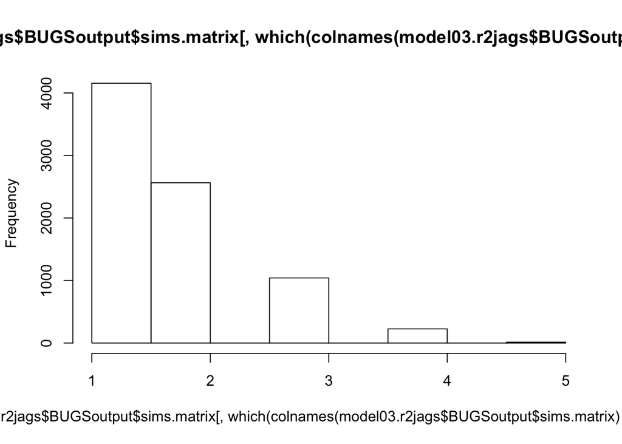

```r
hist(model03.r2jags$BUGSoutput$sims.matrix[,which(colnames(model03.r2jags$BUGSoutput$sims.matrix)=="item1[4]")])
```

```r
conspiracy[1:10,1:3]
```

```
##    PolConsp1 PolConsp2 PolConsp3
## 1          2         1         2
## 2          3         2         4
## 3          4         4         2
## 4         NA         1         1
## 5          2         2         1
## 6          1         1         1
## 7          4         2         1
## 8          2         4         1
## 9          3         2         1
## 10         2         2         1
```

And look at how the posterior distribution of $\theta_p$ changes by removing that one observation. The dashed line is the posterior distribution from an observation with the same response pattern but complete data.

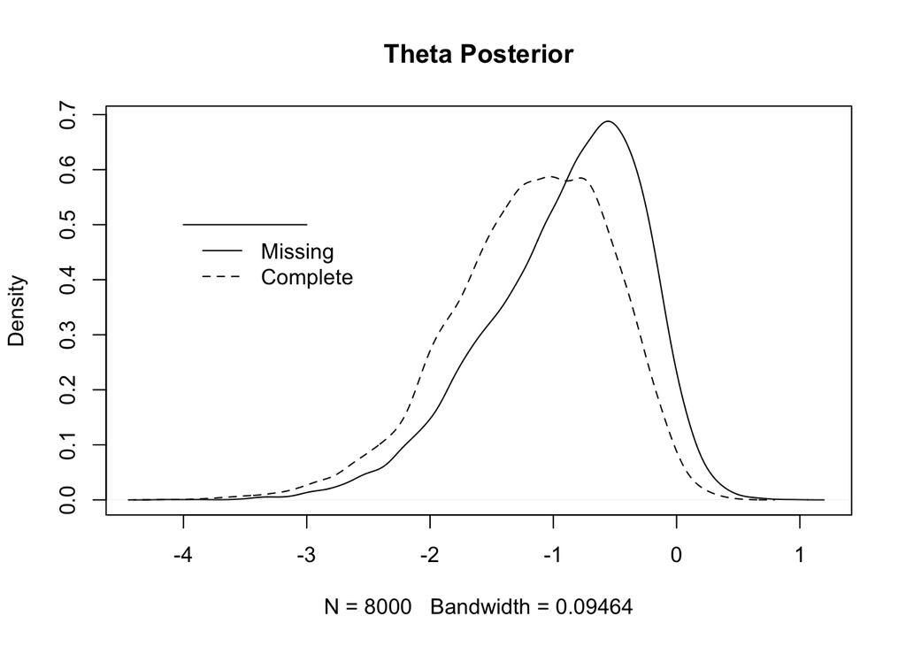

```r
par(mfrow = c(1,1))
plot(density(model03.r2jags$BUGSoutput$sims.matrix[,which(colnames(model03.r2jags$BUGSoutput$sims.matrix)=="theta[4]")]), main = "Theta Posterior")
lines(density(model03.r2jags$BUGSoutput$sims.matrix[,which(colnames(model03.r2jags$BUGSoutput$sims.matrix)=="theta[6]")]), lty=2)
legend(x = c(-4, -3), y = c(.5, .5), legend = c("Missing", "Complete"), lty=1:2)
```